fossil

# Yu and Shaw, dug back up.

Its data, its algorithm, four figures and Table 1 are back.

Read the code analysis

## Fig. 2

The function implementing (6) is unstable when ψ approaches 0. x = (2, 3, 1), p = (.2, .3, .5).

AgreesIdentical data

Published

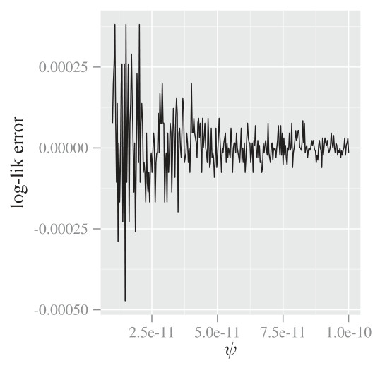

Reproduction in ggplot2 and tikzDevice

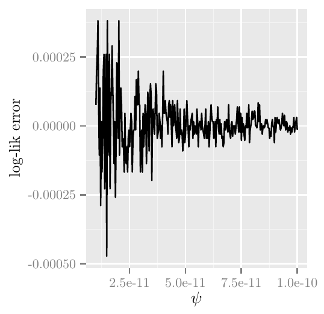

**Pixel size**

538 × 521

**Drawn at**

3.25 × 3.21 in

**Rasterised**

166 dpi

**Panel fill**

#E9E9E9

**Mean |Δ| grey**

8.02

**Pixels within ±24**

90.7%

Same data as the paper. ψ = seq(1e-11, 1e-10, length.out = 300); Eq. (6) evaluated as R’s lgammafn with x86 (no-FMA) arithmetic and 80-bit sum(). The curve covers 100% of the paper’s curve pixels and vice versa.

## Fig. 4

Mesh vs aod(dirmult) when ψ varies near 0. x = (2, 3, 1), p = (.2, .3, .5).

AgreesIdentical data

Published

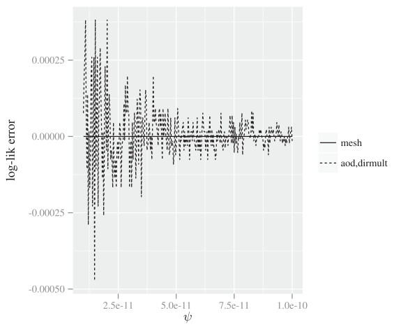

Reproduction in ggplot2 and tikzDevice

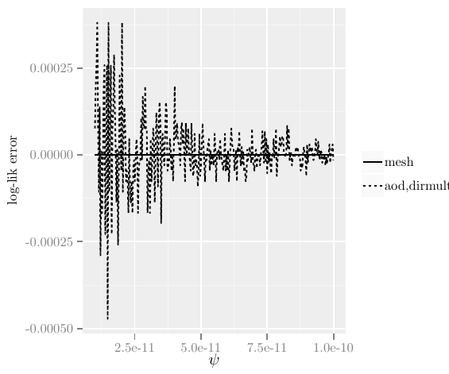

**Pixel size**

565 × 471

**Drawn at**

4.82 × 3.86 in

**Rasterised**

125 dpi

**Panel fill**

#EEEEEE

**Mean |Δ| grey**

7.91

**Pixels within ±24**

93.1%

The aod,dirmult curve is the Fig. 2 series, identical to the paper. The mesh values come from the authors’ compiled library (lldmn); their error is below 1e-15, so the line is flat at this scale, as in the paper.

## Fig. 5

Error of mesh vs the method in VGAM. x = n(1, 1, 1, 1), ψ = 1/200, p = (.1, .2, .3, .4).

Partly agreesSame setup, ulp noise differs

Published

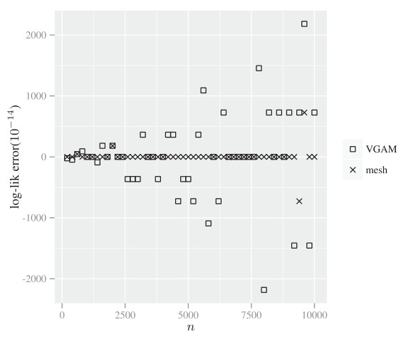

Reproduction in ggplot2 and tikzDevice

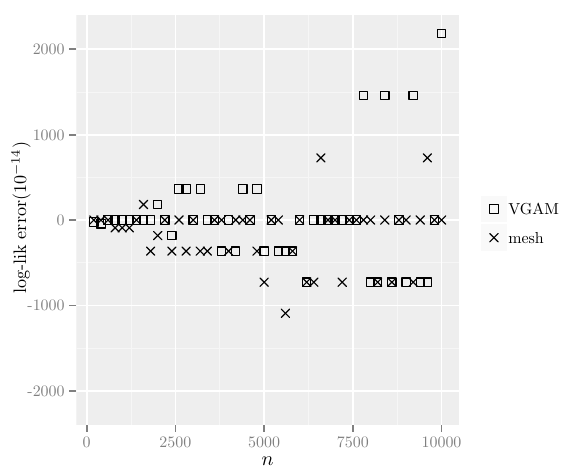

**Pixel size**

570 × 473

**Drawn at**

4.88 × 4.02 in

**Rasterised**

120 dpi

**Panel fill**

#EEEEEE

**Mean |Δ| grey**

4.52

**Pixels within ±24**

96.7%

Shown on the paper’s y-axis (−2395 to 2401 × 10⁻¹⁴, gridlines every 1000), so the frame and tick labels coincide; none of our points fall outside it. Same n grid (200…10000, step 200), with errors counted in whole ulps as in the paper. The ulp-level noise depends on the exact 2013 build: our VGAM R code reproduces 26 of the 50 published marks, and the authors’ mesh library run here under Rosetta gives 1 to 3 ulp errors where the paper shows 0.

## Fig. 6

Runtime of mesh vs VGAM, 100 evaluations per box. x = n(1, 2, 3), p = (1/6, 1/3, 1/2), ψ = 1/60.

Partly agreesRe-timed, scaled to the paper’s axis

Published

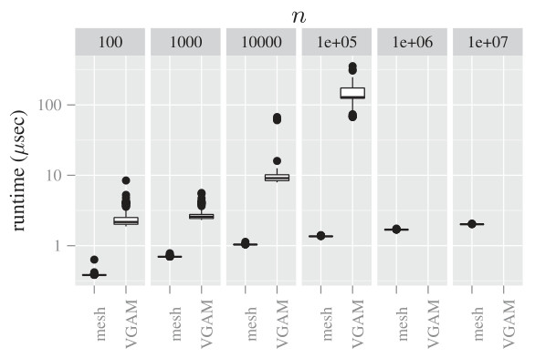

Reproduction in ggplot2 and tikzDevice

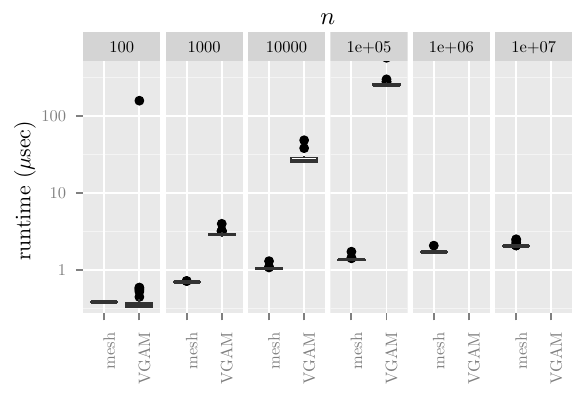

**Pixel size**

586 × 393

**Drawn at**

4.76 × 3.31 in

**Rasterised**

124 dpi

**Panel fill**

#E9E9E9

**Mean |Δ| grey**

6.34

**Pixels within ±24**

95.2%

Shown on the paper’s own axis (0.27 to 510 µs; breaks 1, 10, 100). Timings were measured on this Mac, then each method was divided by one constant fitted to the paper’s box medians (least squares in log10): mesh ÷13.2, VGAM ÷27.3. Mesh runs 13.2 to 13.3× slower than the paper’s at every n, so after that one constant its growth with n matches the paper exactly. For VGAM the ratio climbs from 4.3× (n = 100) to 77× (n = 10⁴): our R code for Eq. (7) grows linearly with n, while the paper’s VGAM barely changes between n = 100 and 1000 (2.1 to 2.5 µs). One VGAM outlier at 10⁵ falls above the axis and is clipped.

## Table 1

The MLE of the dispersion parameters of the 16S rRNA pyrosequencing data from all four body sites.

AgreesAll four match to 5 decimals

Published

| Body site | *ψ* |
| --- | --- |
| Saliva | 0.00389 |
| Throat | 0.00639 |
| Tongue | 0.00802 |
| Tonsils | 0.01039 |

Reproduced

| Body site | *ψ* |
| --- | --- |
| Saliva | 0.00389 |
| Throat | 0.00639 |
| Tongue | 0.00802 |
| Tonsils | 0.01039 |

| Body site | Samples | Reads | MLE *ψ* (6 d.p.) | Paper | Match |
| --- | --- | --- | --- | --- | --- |
| Saliva | 24 | 562,790 | 0.003892 | 0.00389 | ✓ |
| Throat | 23 | 444,670 | 0.006394 | 0.00639 | ✓ |
| Tongue | 24 | 572,903 | 0.008016 | 0.00802 | ✓ |
| Tonsils | 23 | 490,257 | 0.010388 | 0.01039 | ✓ |

Data: the HMP saliva, throat, tongue and tonsils count matrices (21 taxa) from the archived CRAN package HMP 2.0.1 (Apache-2.0). Maximum likelihood over all 21 Dirichlet parameters, with the log-likelihood from the mesh algorithm and exact digamma gradients (L-BFGS-B, four starting values of ψ, each fit in about 0.1 s). Checks: the plain lgamma formula agrees with mesh at the optimum to within 5e-10, and a ψ scan peaks at the fitted value. A separate pure-Python fit with finite-difference gradients (about 20 min per site) gives the same ψ to six decimals.

## What we matched

Each reproduction is drawn with ggplot2 through tikzDevice and pdfLaTeX, the toolchain the paper’s typography points to. It is styled with ggplot2’s 2013 defaults and rendered at the published figure’s exact pixel size, so the two images can be laid over each other directly.

**Package and theme**

ggplot2 with the 0.9.3 theme_grey defaults restated: grey panel, white major and lighter minor gridlines, grey50 axis text at 0.8×, 0.15 cm ticks, grey95 legend keys of 1.2 lines, grey80 strips.

**Fonts**

tikzDevice, then pdfLaTeX, in Computer Modern, the LaTeX default, with *ψ*, *n*, *μ* and 10<sup>−14</sup> set in math mode as in the paper. Times scored within a few percent on stroke alignment, so at this resolution the typeface can’t be identified with certainty.

**Lines**

72.27/96 pt per lwd (R’s own convention) instead of current tikzDevice’s 0.4 pt, which matches the published lines of about 1 pt. Dashes are 2 pt on, 2 pt off, as measured in Fig. 4.

**Colours**

Panel and strip fills sampled from the published JPEGs. These read lighter than ggplot’s grey90 (#E5E5E5): #E9E9E9 in Figs 2 and 6, #EEEEEE in Figs 4 and 5. Strips read #D4D4D4 rather than grey80 (#CCCCCC). Text keeps ggplot’s black and grey50.

**Size**

Drawing size and raster resolution fitted per figure so the panel lands on the published pixels, then cropped to the published frame (538×521, 565×471, 570×473 and 586×393 px).

**Spacing**

Axis-title gaps, legend position and y-title sizes tuned per figure by local alignment. ggplot2 0.9.3 laid out title rows differently from 4.x, and the published y-titles measure 9.9 to 12.7 pt rather than a uniform 12 pt.

## The session

Session not recorded: no log of the agent session was kept for this reproduction.